# Assignment1

Peng Yuan

2023-02-16

## Q1: Interpreting regression results and p-values.

**If the p-value of the null hypothesis is small (usually less than 0.05), we will reject the null hypothesis and conclude that there is a relationship between the independent variable and sales. If the p-value is large (usually greater than 0.05), we can conclude that there is no evidence of a relationship between the independent variable and sales.**

**Null hypothesis for TV as H0: Because the p-value of TV is less than 0.0001, so we have enough evidence to reject null hypothesis and we can consider that TV advertising budgets have significant effect on product sales.**

**Null hypothesis for radio as H0: Because the p-value of radio is less than 0.0001, so we have enough evidence to reject null hypothesis and we can consider that radio have significant effect on product sales.**

**Null hypothesis for newspaper as H0: Because the p-value of newspaper is 0.8599, so we don’t have enough evidence to reject null hypothesis and we can consider that newspaper advertising budgets have no effect on product sales.**

## Q3: interpreting interactions.

### a

**i** Incorrect. When the IQ and GPA is fixed, the function for salary is:
$$Salary = 50 + 20 \times GPA + 0.07 \times IQ + 35 \times Level + 0.01
\times GPA \times IQ - 10 \times GPA \times Level
\\ = (35 - 10 \times GPA)\times Level + 50 + 20 \times GPA + 0.07 \times
IQ + 0.01 \times GPA \times IQ$$
When their GPA is higher than 3.5, high school graduates earn more. Otherwise, college graduates earn more. Thus, we can’t consider that high school graduates earn more, on average, than college graduates.

**ii** Incorrect. The reason is the same as the one mentioned in answer i. When their GPA is lower than 3.5, college graduates earn more. Otherwise, high school graduates earn more.

**iii** Correct. because when the GPA is higher than 3.5, the 35 - 10 x GPA in the formula mentioned in i will be less than 0. This is when high school graduates earn more on average than college graduates for a fixed IQ and GPA.

**iv** Same reason as iii, therefore incorrect

### b

Bring IQ = 110, GPA = 4.0 into the equation of a.i for calculation. salary = 137.1.

### c

False. If we want to check the interaction between two variables, we need to see the p-value instead of the coefficient. Even if the value of coefficient for interaction term is very small, we can’t say there is very little interaction effect.

## Q10: regression analysis of carseats data (ISLR package).

```r
library(ISLR)
```

**(a) Fit a multiple regression model to predict Sales using Price, Urban, and US**

```r
fit = lm(Sales ~ Price + Urban + US, data = Carseats)
summary(fit)
```

```
##
## Call:
## lm(formula = Sales ~ Price + Urban + US, data = Carseats)
##
## Residuals:
##     Min      1Q  Median      3Q     Max
## -6.9206 -1.6220 -0.0564  1.5786  7.0581
##
## Coefficients:
##              Estimate Std. Error t value Pr(>|t|)
## (Intercept) 13.043469   0.651012  20.036  < 2e-16 ***
## Price       -0.054459   0.005242 -10.389  < 2e-16 ***
## UrbanYes    -0.021916   0.271650  -0.081    0.936
## USYes        1.200573   0.259042   4.635 4.86e-06 ***
## ---
## Signif. codes:  0 '***' 0.001 '**' 0.01 '*' 0.05 '.' 0.1 ' ' 1
##
## Residual standard error: 2.472 on 396 degrees of freedom
## Multiple R-squared:  0.2393, Adjusted R-squared:  0.2335
## F-statistic: 41.52 on 3 and 396 DF,  p-value: < 2.2e-16
```

**(b) Provide an interpretation of each coefficient in the model. Be careful—some of the variables in the model are qualitative!** “Price”: According to it’s p-value(less than 2e-16), it can be considered as an important value. According to it’s Estimate, we can know that when the price increase one unit, the sales will decrease 0.054459 unit.

“Urban”: According to it’s p-value(0.936), it can’t be considered as an important value.

**(c) Write out the model in equation form, being careful to handle the qualitative variables properly.**

Sales = 13.043469 - 0.054459 x Price - 0.021916 x Urban + 1.200573 x US

**(d) For which of the predictors can you reject the null hypothesis H0 : βj = 0?**

For ‘Price’ and ‘US’, I think we can reject the null hypothesis because their p-value are less than 0.05.

**(e)On the basis of your response to the previous question, fit a smaller model that only uses the predictors for which there is evidence of association with the outcome.**

```r
fit_Sales_Price_US = lm(Sales ~ Price  + US, data = Carseats)
summary(fit_Sales_Price_US)
```

```
##
## Call:
## lm(formula = Sales ~ Price + US, data = Carseats)
##
## Residuals:
##     Min      1Q  Median      3Q     Max
## -6.9269 -1.6286 -0.0574  1.5766  7.0515
##
## Coefficients:
##             Estimate Std. Error t value Pr(>|t|)
## (Intercept) 13.03079    0.63098  20.652  < 2e-16 ***
## Price       -0.05448    0.00523 -10.416  < 2e-16 ***
## USYes        1.19964    0.25846   4.641 4.71e-06 ***
## ---
## Signif. codes:  0 '***' 0.001 '**' 0.01 '*' 0.05 '.' 0.1 ' ' 1
##
## Residual standard error: 2.469 on 397 degrees of freedom
## Multiple R-squared:  0.2393, Adjusted R-squared:  0.2354
## F-statistic: 62.43 on 2 and 397 DF,  p-value: < 2.2e-16
```

**(f) How well do the models in (a) and (e) fit the data?**

The overall standard error, p-value, of both Price and US decreases in (e) and the Adjusted R-squared of the model increases. This indicates that the values of model e look more like a good model relative to model a.

**(g) Using the model from (e), obtain 95 % confidence intervals for the coefficient(s).**

```r
confint(fit_Sales_Price_US, level = 0.95)
```

```
##                   2.5 %      97.5 %
## (Intercept) 11.79032020 14.27126531
## Price       -0.06475984 -0.04419543
## USYes        0.69151957  1.70776632
```

**(h) Is there evidence of outliers or high leverage observations in the model from (e)?**

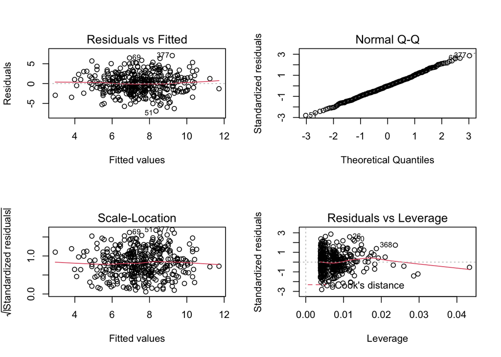

```r
par(mfrow=c(2,2))
plot(fit_Sales_Price_US)
```

## Q15: regression analysis of Boston housing data (MASS package)

```r
library(MASS)
library(ggplot2)
```

**(a) For each predictor, fit a simple linear regression model to predict the response. Describe your results. In which of the models is there a statistically significant association between the predictor and the response? Create some plots to back up your assertions**

```r
fit_zn <- lm(crim ~ zn, data = Boston)
fit_indus <- lm(crim ~ indus, data = Boston)
fit_chas <- lm(crim ~ chas, data = Boston)
fit_nox <- lm(crim ~ nox, data = Boston)
fit_rm <- lm(crim ~ rm, data = Boston)
fit_age <- lm(crim ~ age, data = Boston)
fit_dis <- lm(crim ~ dis, data = Boston)
fit_rad <- lm(crim ~ rad, data = Boston)
fit_tax <- lm(crim ~ tax, data = Boston)
fit_ptratio <- lm(crim ~ ptratio, data = Boston)
fit_black <- lm(crim ~ black, data = Boston)
fit_lstat <- lm(crim ~ lstat, data = Boston)
fit_medv <- lm(crim ~ medv, data = Boston)
```

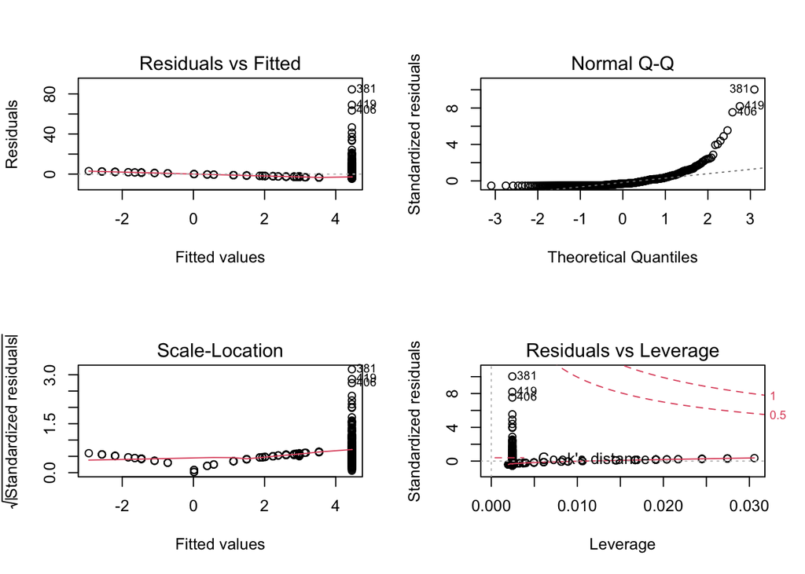

```r
par(mfrow=c(2,2))
plot(fit_zn)
```

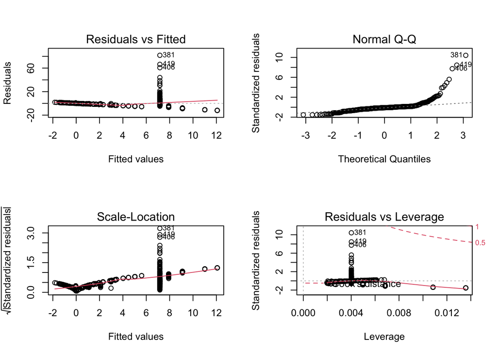

```r
par(mfrow=c(2,2))
plot(fit_indus)
```

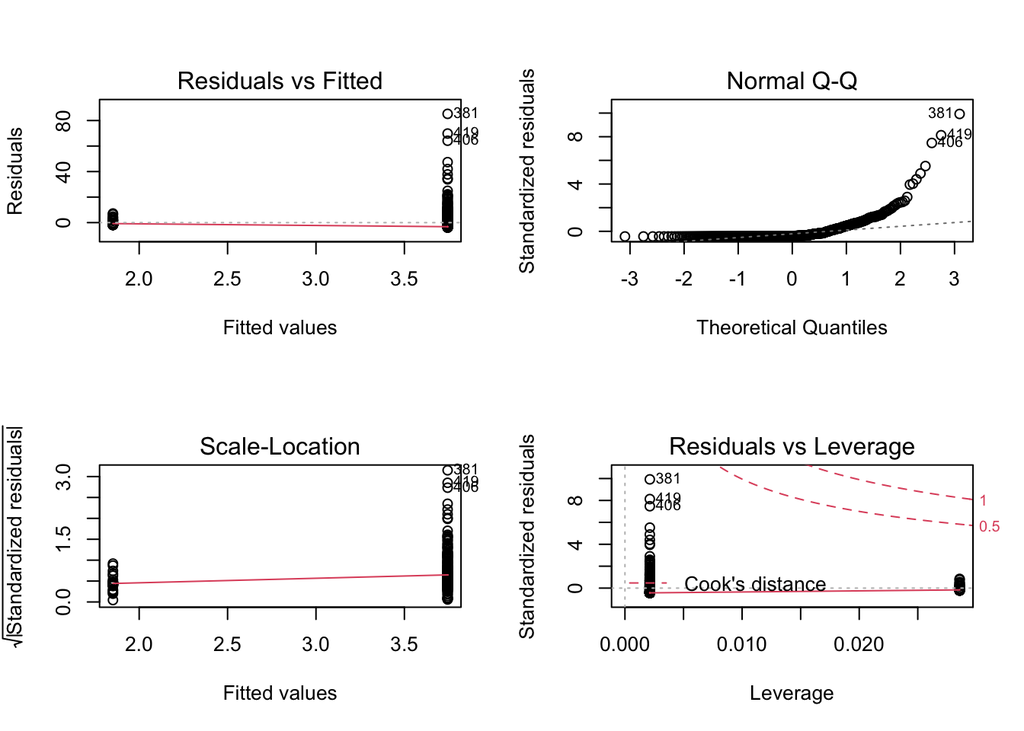

```r
par(mfrow=c(2,2))
plot(fit_chas)
```

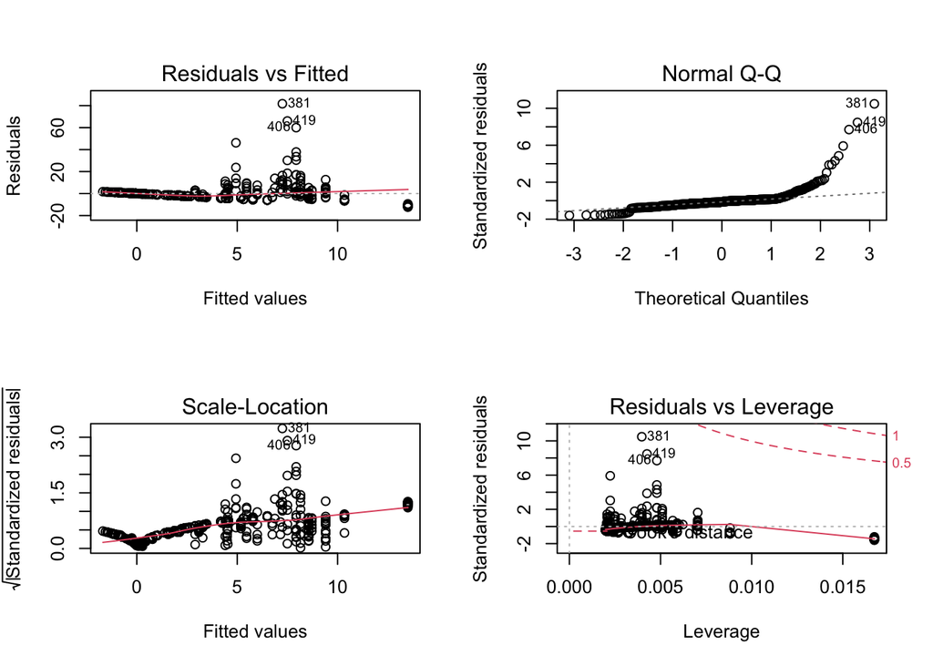

```r
par(mfrow=c(2,2))
plot(fit_nox)
```

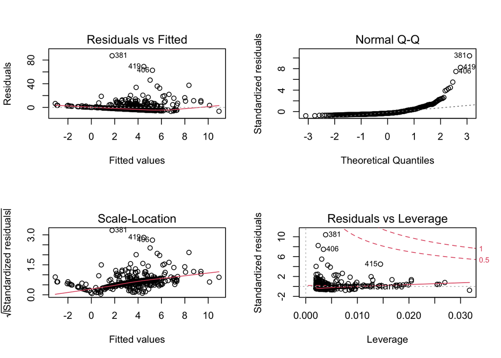

```r
par(mfrow=c(2,2))
plot(fit_rm)
```

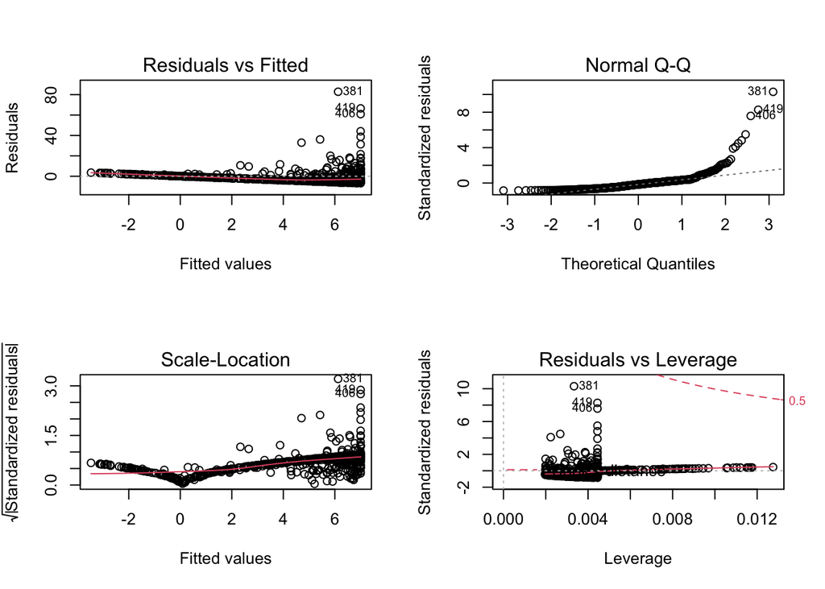

```r
par(mfrow=c(2,2))
plot(fit_age)
```

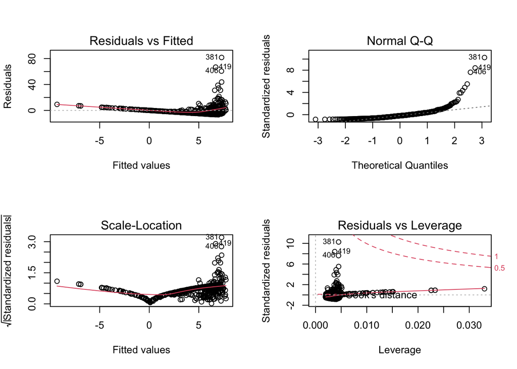

```r
par(mfrow=c(2,2))
plot(fit_dis)
```

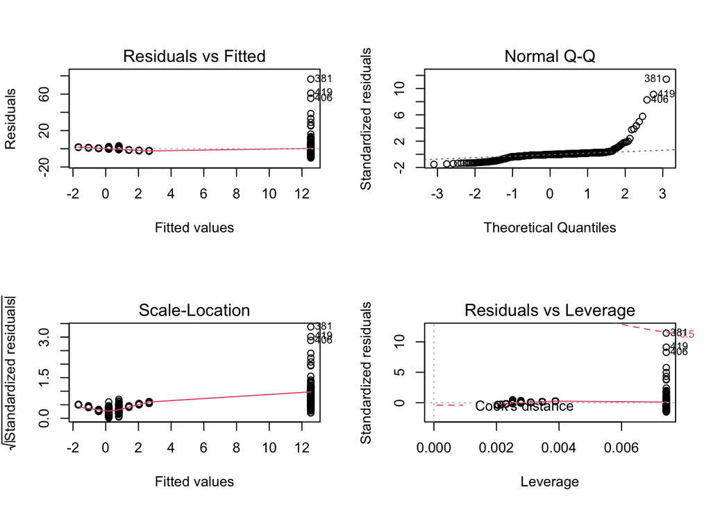

```r
par(mfrow=c(2,2))
plot(fit_rad)
```

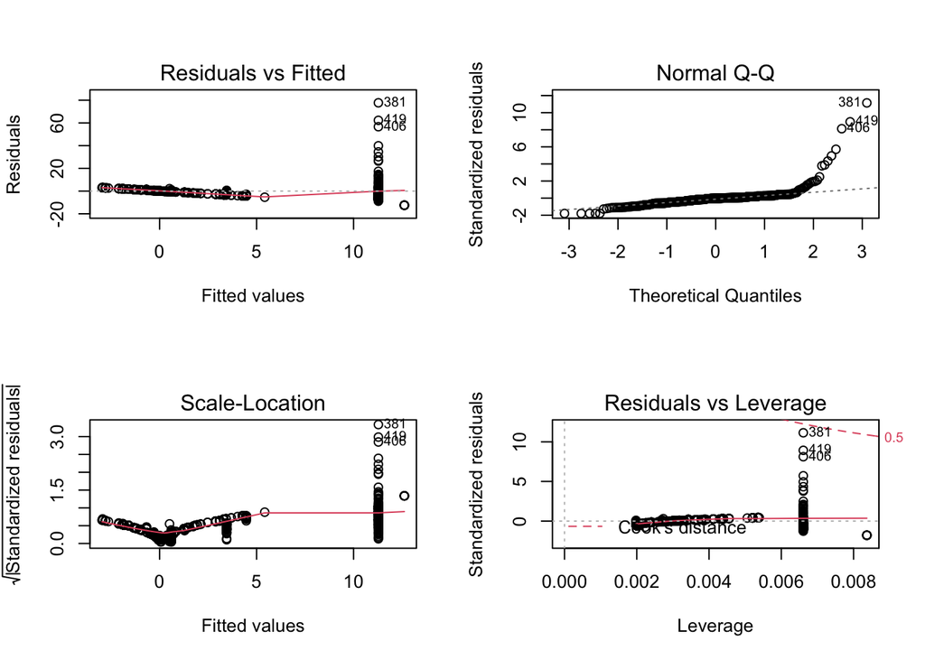

```r
par(mfrow=c(2,2))
plot(fit_tax)
```

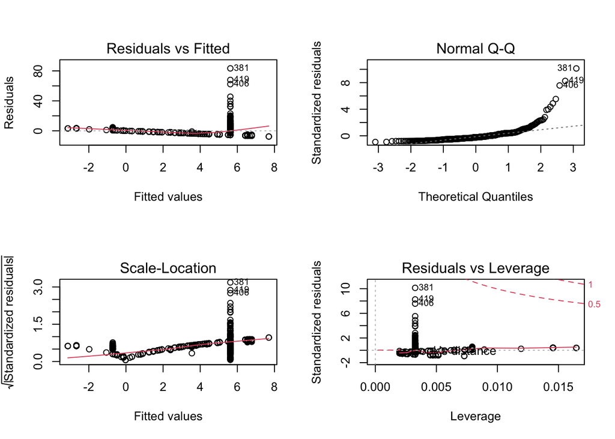

```r
par(mfrow=c(2,2))
plot(fit_ptratio)
```

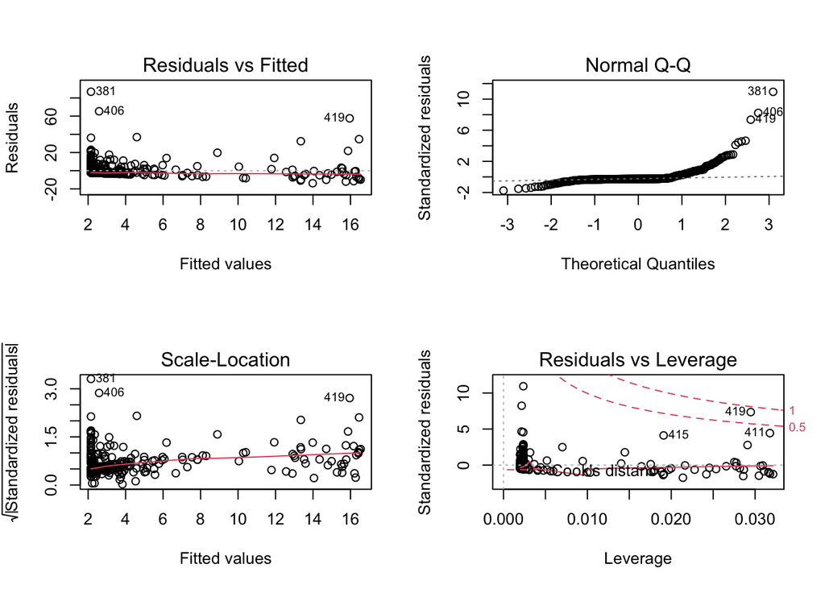

```r
par(mfrow=c(2,2))
plot(fit_black)
```

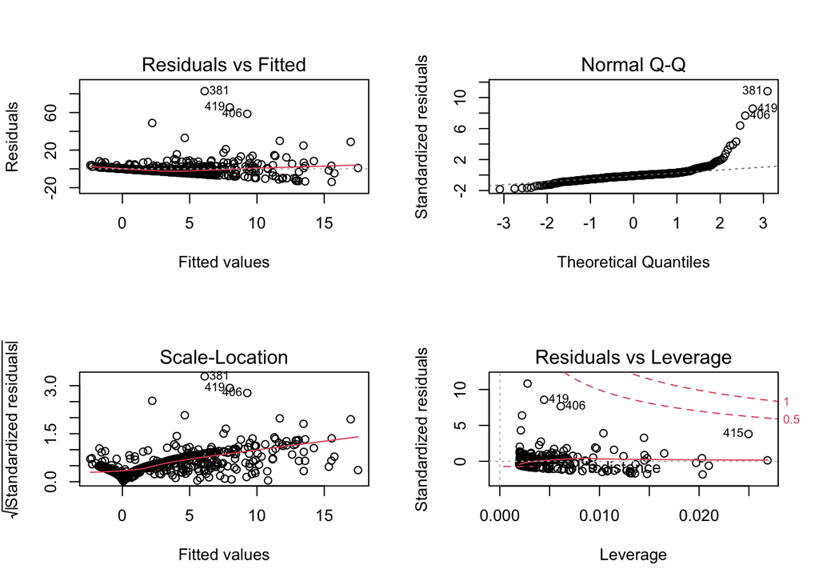

```r
par(mfrow=c(2,2))
plot(fit_lstat)
```

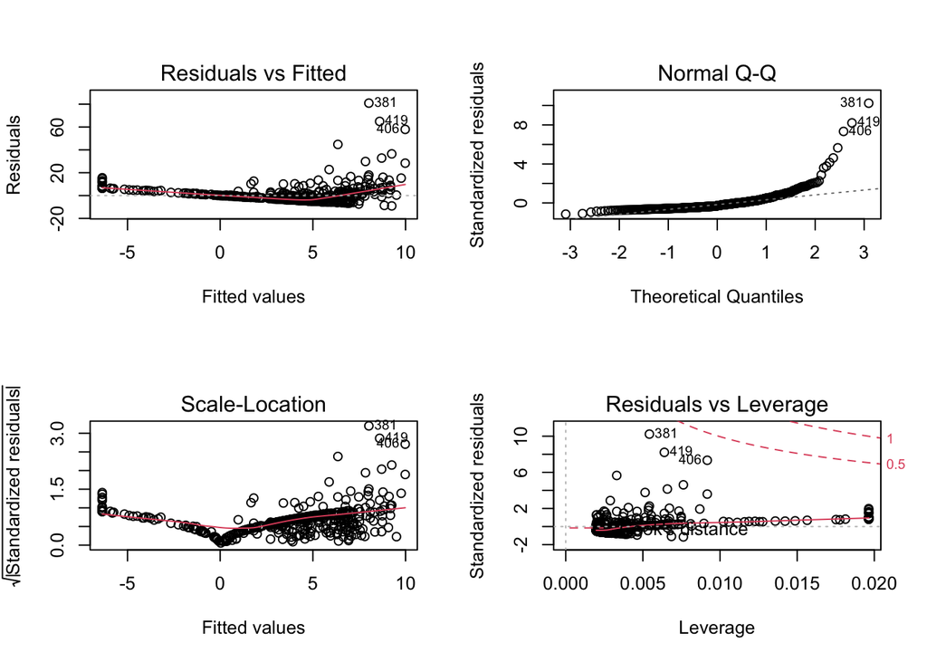

```r
par(mfrow=c(2,2))
plot(fit_medv)
```

**For all variables, except chas are significant.**

**(b)Fit a multiple regression model to predict the response using all of the predictors. Describe your results. For which predictors can we reject the null hypothesis H0 : βj = 0?**

```r
lm_fit3 = lm(crim ~., data = Boston)
summary(lm_fit3)
```

```
##
## Call:
## lm(formula = crim ~ ., data = Boston)
##
## Residuals:
##    Min     1Q Median     3Q    Max
## -9.924 -2.120 -0.353  1.019 75.051
##
## Coefficients:
##               Estimate Std. Error t value Pr(>|t|)
## (Intercept)  17.033228   7.234903   2.354 0.018949 *
## zn            0.044855   0.018734   2.394 0.017025 *
## indus        -0.063855   0.083407  -0.766 0.444294
## chas         -0.749134   1.180147  -0.635 0.525867
## nox         -10.313535   5.275536  -1.955 0.051152 .
## rm            0.430131   0.612830   0.702 0.483089
## age           0.001452   0.017925   0.081 0.935488
## dis          -0.987176   0.281817  -3.503 0.000502 ***
## rad           0.588209   0.088049   6.680 6.46e-11 ***
## tax          -0.003780   0.005156  -0.733 0.463793
## ptratio      -0.271081   0.186450  -1.454 0.146611
## black        -0.007538   0.003673  -2.052 0.040702 *
## lstat         0.126211   0.075725   1.667 0.096208 .
## medv         -0.198887   0.060516  -3.287 0.001087 **
## ---
## Signif. codes:  0 '***' 0.001 '**' 0.01 '*' 0.05 '.' 0.1 ' ' 1
##
## Residual standard error: 6.439 on 492 degrees of freedom
## Multiple R-squared:  0.454,  Adjusted R-squared:  0.4396
## F-statistic: 31.47 on 13 and 492 DF,  p-value: < 2.2e-16
```

**For zn, dis, rad, black and medv, we can reject the null hypothesis.**

**(c) How do your results from (a) compare to your results from (b)?Create a plot displaying the univariate regression coefficients from (a) on the x-axis, and the multiple regression coefficients from (b) on the y-axis. That is, each predictor is displayed as a single point in the plot. Its coefficient in a simple linear regression model is shown on the x-axis, and its coefficient estimatein the multiple linear regression model is shown on the y-axis.**

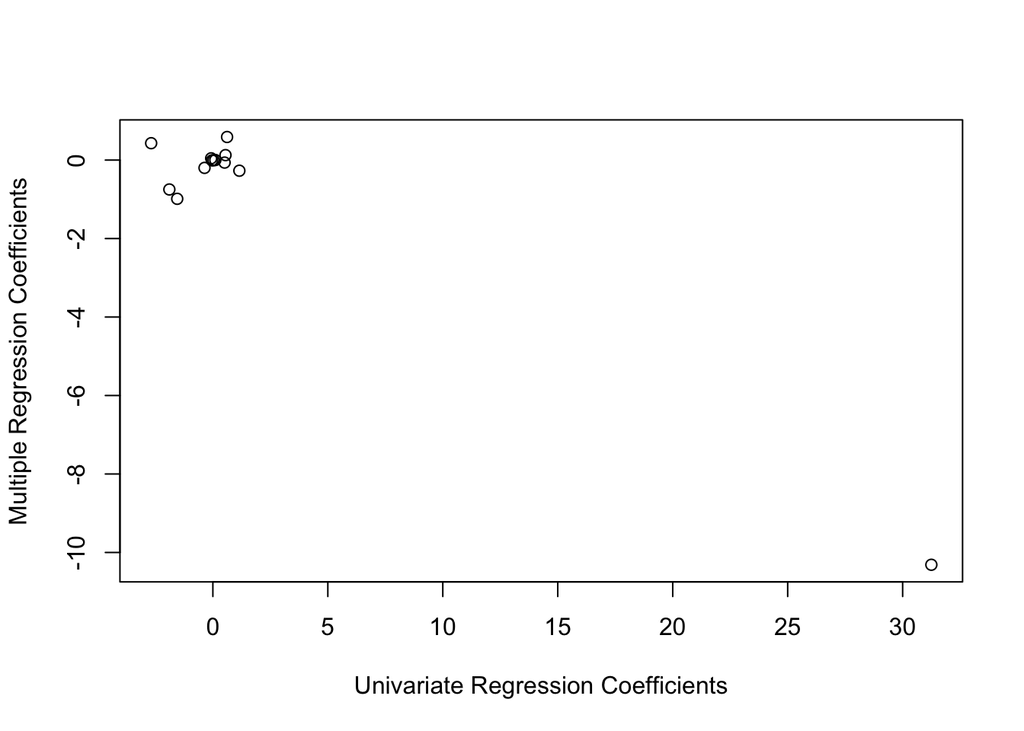

```r
x_variable <- c(coefficients(fit_zn)[2],
                coefficients(fit_indus)[2],
                coefficients(fit_chas)[2],
                coefficients(fit_nox)[2],
                coefficients(fit_rm)[2],
                coefficients(fit_age)[2],
                coefficients(fit_dis)[2],
                coefficients(fit_rad)[2],
                coefficients(fit_tax)[2],
                coefficients(fit_ptratio)[2],
                coefficients(fit_black)[2],
                coefficients(fit_lstat)[2],
                coefficients(fit_medv)[2])

y_variable <- c(coefficients(lm_fit3)[2:14])


plot(x_variable,y_variable,xlab = "Univariate Regression Coefficients", ylab = "Multiple Regression Coefficients")
```

**Only ‘nox’ has a huge difference.**

**(d) Is there evidence of non-linear association between any of the predictors and the response? To answer this question, for each predictor X, fit a model of the form**
$$Y = \beta_0 + \beta_1X + \beta_1X^2 + \beta_3X^3 + \epsilon$$

```r
fit_zn_muti <- lm(crim ~ zn + I(zn^2) + I(zn^3), data = Boston)
summary(fit_zn_muti)
```

```
##
## Call:
## lm(formula = crim ~ zn + I(zn^2) + I(zn^3), data = Boston)
##
## Residuals:
##    Min     1Q Median     3Q    Max
## -4.821 -4.614 -1.294  0.473 84.130
##
## Coefficients:
##               Estimate Std. Error t value Pr(>|t|)
## (Intercept)  4.846e+00  4.330e-01  11.192  < 2e-16 ***
## zn          -3.322e-01  1.098e-01  -3.025  0.00261 **
## I(zn^2)      6.483e-03  3.861e-03   1.679  0.09375 .
## I(zn^3)     -3.776e-05  3.139e-05  -1.203  0.22954
## ---
## Signif. codes:  0 '***' 0.001 '**' 0.01 '*' 0.05 '.' 0.1 ' ' 1
##
## Residual standard error: 8.372 on 502 degrees of freedom
## Multiple R-squared:  0.05824,    Adjusted R-squared:  0.05261
## F-statistic: 10.35 on 3 and 502 DF,  p-value: 1.281e-06
```

```r
fit_indus_muti <- lm(crim ~ indus + I(indus^2) + I(indus^3), data = Boston)
summary(fit_indus_muti)
```

```
##
## Call:
## lm(formula = crim ~ indus + I(indus^2) + I(indus^3), data = Boston)
##
## Residuals:
##    Min     1Q Median     3Q    Max
## -8.278 -2.514  0.054  0.764 79.713
##
## Coefficients:
##               Estimate Std. Error t value Pr(>|t|)
## (Intercept)  3.6625683  1.5739833   2.327   0.0204 *
## indus       -1.9652129  0.4819901  -4.077 5.30e-05 ***
## I(indus^2)   0.2519373  0.0393221   6.407 3.42e-10 ***
## I(indus^3)  -0.0069760  0.0009567  -7.292 1.20e-12 ***
## ---
## Signif. codes:  0 '***' 0.001 '**' 0.01 '*' 0.05 '.' 0.1 ' ' 1
##
## Residual standard error: 7.423 on 502 degrees of freedom
## Multiple R-squared:  0.2597, Adjusted R-squared:  0.2552
## F-statistic: 58.69 on 3 and 502 DF,  p-value: < 2.2e-16
```

```r
fit_chas_muti <- lm(crim ~ chas + I(chas^2) + I(chas^3), data = Boston)
summary(fit_chas_muti)
```

```
##
## Call:
## lm(formula = crim ~ chas + I(chas^2) + I(chas^3), data = Boston)
##
## Residuals:
##    Min     1Q Median     3Q    Max
## -3.738 -3.661 -3.435  0.018 85.232
##
## Coefficients: (2 not defined because of singularities)
##             Estimate Std. Error t value Pr(>|t|)
## (Intercept)   3.7444     0.3961   9.453   <2e-16 ***
## chas         -1.8928     1.5061  -1.257    0.209
## I(chas^2)         NA         NA      NA       NA
## I(chas^3)         NA         NA      NA       NA
## ---
## Signif. codes:  0 '***' 0.001 '**' 0.01 '*' 0.05 '.' 0.1 ' ' 1
##
## Residual standard error: 8.597 on 504 degrees of freedom
## Multiple R-squared:  0.003124,   Adjusted R-squared:  0.001146
## F-statistic: 1.579 on 1 and 504 DF,  p-value: 0.2094
```

```r
fir_nox_muti <- lm(crim ~ nox + I(nox^2) + I(nox^3), data = Boston)
summary(fir_nox_muti)
```

```
##
## Call:
## lm(formula = crim ~ nox + I(nox^2) + I(nox^3), data = Boston)
##
## Residuals:
##    Min     1Q Median     3Q    Max
## -9.110 -2.068 -0.255  0.739 78.302
##
## Coefficients:
##             Estimate Std. Error t value Pr(>|t|)
## (Intercept)   233.09      33.64   6.928 1.31e-11 ***
## nox         -1279.37     170.40  -7.508 2.76e-13 ***
## I(nox^2)     2248.54     279.90   8.033 6.81e-15 ***
## I(nox^3)    -1245.70     149.28  -8.345 6.96e-16 ***
## ---
## Signif. codes:  0 '***' 0.001 '**' 0.01 '*' 0.05 '.' 0.1 ' ' 1
##
## Residual standard error: 7.234 on 502 degrees of freedom
## Multiple R-squared:  0.297,  Adjusted R-squared:  0.2928
## F-statistic: 70.69 on 3 and 502 DF,  p-value: < 2.2e-16
```

```r
fit_rm_muti <- lm(crim ~ rm + I(rm^2) + I(rm^3), data = Boston)
summary(fit_rm_muti)
```

```
##
## Call:
## lm(formula = crim ~ rm + I(rm^2) + I(rm^3), data = Boston)
##
## Residuals:
##     Min      1Q  Median      3Q     Max
## -18.485  -3.468  -2.221  -0.015  87.219
##
## Coefficients:
##             Estimate Std. Error t value Pr(>|t|)
## (Intercept) 112.6246    64.5172   1.746   0.0815 .
## rm          -39.1501    31.3115  -1.250   0.2118
## I(rm^2)       4.5509     5.0099   0.908   0.3641
## I(rm^3)      -0.1745     0.2637  -0.662   0.5086
## ---
## Signif. codes:  0 '***' 0.001 '**' 0.01 '*' 0.05 '.' 0.1 ' ' 1
##
## Residual standard error: 8.33 on 502 degrees of freedom
## Multiple R-squared:  0.06779,    Adjusted R-squared:  0.06222
## F-statistic: 12.17 on 3 and 502 DF,  p-value: 1.067e-07
```

```r
fit_age_muti <- lm(crim ~ age + I(age^2) + I(age^3), data = Boston)
summary(fit_age_muti)
```

```
##
## Call:
## lm(formula = crim ~ age + I(age^2) + I(age^3), data = Boston)
##
## Residuals:
##    Min     1Q Median     3Q    Max
## -9.762 -2.673 -0.516  0.019 82.842
##
## Coefficients:
##               Estimate Std. Error t value Pr(>|t|)
## (Intercept) -2.549e+00  2.769e+00  -0.920  0.35780
## age          2.737e-01  1.864e-01   1.468  0.14266
## I(age^2)    -7.230e-03  3.637e-03  -1.988  0.04738 *
## I(age^3)     5.745e-05  2.109e-05   2.724  0.00668 **
## ---
## Signif. codes:  0 '***' 0.001 '**' 0.01 '*' 0.05 '.' 0.1 ' ' 1
##
## Residual standard error: 7.84 on 502 degrees of freedom
## Multiple R-squared:  0.1742, Adjusted R-squared:  0.1693
## F-statistic: 35.31 on 3 and 502 DF,  p-value: < 2.2e-16
```

```r
fit_dis_muti <- lm(crim ~ dis + I(dis^2) + I(dis^3), data = Boston)
summary(fit_dis_muti)
```

```
##
## Call:
## lm(formula = crim ~ dis + I(dis^2) + I(dis^3), data = Boston)
##
## Residuals:
##     Min      1Q  Median      3Q     Max
## -10.757  -2.588   0.031   1.267  76.378
##
## Coefficients:
##             Estimate Std. Error t value Pr(>|t|)
## (Intercept)  30.0476     2.4459  12.285  < 2e-16 ***
## dis         -15.5543     1.7360  -8.960  < 2e-16 ***
## I(dis^2)      2.4521     0.3464   7.078 4.94e-12 ***
## I(dis^3)     -0.1186     0.0204  -5.814 1.09e-08 ***
## ---
## Signif. codes:  0 '***' 0.001 '**' 0.01 '*' 0.05 '.' 0.1 ' ' 1
##
## Residual standard error: 7.331 on 502 degrees of freedom
## Multiple R-squared:  0.2778, Adjusted R-squared:  0.2735
## F-statistic: 64.37 on 3 and 502 DF,  p-value: < 2.2e-16
```

```r
fit_rad_muti <- lm(crim ~ rad + I(rad^2) + I(rad^3), data = Boston)
summary(fit_rad_muti)
```

```
##
## Call:
## lm(formula = crim ~ rad + I(rad^2) + I(rad^3), data = Boston)
##
## Residuals:
##     Min      1Q  Median      3Q     Max
## -10.381  -0.412  -0.269   0.179  76.217
##
## Coefficients:
##              Estimate Std. Error t value Pr(>|t|)
## (Intercept) -0.605545   2.050108  -0.295    0.768
## rad          0.512736   1.043597   0.491    0.623
## I(rad^2)    -0.075177   0.148543  -0.506    0.613
## I(rad^3)     0.003209   0.004564   0.703    0.482
##
## Residual standard error: 6.682 on 502 degrees of freedom
## Multiple R-squared:    0.4,  Adjusted R-squared:  0.3965
## F-statistic: 111.6 on 3 and 502 DF,  p-value: < 2.2e-16
```

```r
fit_tax_muti <- lm(crim ~ tax + I(tax^2) + I(tax^3), data = Boston)
summary(fit_tax_muti)
```

```
##
## Call:
## lm(formula = crim ~ tax + I(tax^2) + I(tax^3), data = Boston)
##
## Residuals:
##     Min      1Q  Median      3Q     Max
## -13.273  -1.389   0.046   0.536  76.950
##
## Coefficients:
##               Estimate Std. Error t value Pr(>|t|)
## (Intercept)  1.918e+01  1.180e+01   1.626    0.105
## tax         -1.533e-01  9.568e-02  -1.602    0.110
## I(tax^2)     3.608e-04  2.425e-04   1.488    0.137
## I(tax^3)    -2.204e-07  1.889e-07  -1.167    0.244
##
## Residual standard error: 6.854 on 502 degrees of freedom
## Multiple R-squared:  0.3689, Adjusted R-squared:  0.3651
## F-statistic:  97.8 on 3 and 502 DF,  p-value: < 2.2e-16
```

```r
fit_ptratio_muti <- lm(crim ~ ptratio + I(ptratio^2) + I(ptratio^3),
                       data = Boston)
summary(fit_ptratio_muti)
```

```
##
## Call:
## lm(formula = crim ~ ptratio + I(ptratio^2) + I(ptratio^3), data = Boston)
##
## Residuals:
##    Min     1Q Median     3Q    Max
## -6.833 -4.146 -1.655  1.408 82.697
##
## Coefficients:
##               Estimate Std. Error t value Pr(>|t|)
## (Intercept)  477.18405  156.79498   3.043  0.00246 **
## ptratio      -82.36054   27.64394  -2.979  0.00303 **
## I(ptratio^2)   4.63535    1.60832   2.882  0.00412 **
## I(ptratio^3)  -0.08476    0.03090  -2.743  0.00630 **
## ---
## Signif. codes:  0 '***' 0.001 '**' 0.01 '*' 0.05 '.' 0.1 ' ' 1
##
## Residual standard error: 8.122 on 502 degrees of freedom
## Multiple R-squared:  0.1138, Adjusted R-squared:  0.1085
## F-statistic: 21.48 on 3 and 502 DF,  p-value: 4.171e-13
```

```r
fit_black_muti <- lm(crim ~ black + I(black^2) + I(black^3), data = Boston)
summary(fit_black_muti)
```

```
##
## Call:
## lm(formula = crim ~ black + I(black^2) + I(black^3), data = Boston)
##
## Residuals:
##     Min      1Q  Median      3Q     Max
## -13.096  -2.343  -2.128  -1.439  86.790
##
## Coefficients:
##               Estimate Std. Error t value Pr(>|t|)
## (Intercept)  1.826e+01  2.305e+00   7.924  1.5e-14 ***
## black       -8.356e-02  5.633e-02  -1.483    0.139
## I(black^2)   2.137e-04  2.984e-04   0.716    0.474
## I(black^3)  -2.652e-07  4.364e-07  -0.608    0.544
## ---
## Signif. codes:  0 '***' 0.001 '**' 0.01 '*' 0.05 '.' 0.1 ' ' 1
##
## Residual standard error: 7.955 on 502 degrees of freedom
## Multiple R-squared:  0.1498, Adjusted R-squared:  0.1448
## F-statistic: 29.49 on 3 and 502 DF,  p-value: < 2.2e-16
```

```r
fit_lstat_muti <- lm(crim ~ lstat + I(lstat^2) + I(lstat^3), data = Boston)
summary(fit_lstat_muti)
```

```
##
## Call:
## lm(formula = crim ~ lstat + I(lstat^2) + I(lstat^3), data = Boston)
##
## Residuals:
##     Min      1Q  Median      3Q     Max
## -15.234  -2.151  -0.486   0.066  83.353
##
## Coefficients:
##               Estimate Std. Error t value Pr(>|t|)
## (Intercept)  1.2009656  2.0286452   0.592   0.5541
## lstat       -0.4490656  0.4648911  -0.966   0.3345
## I(lstat^2)   0.0557794  0.0301156   1.852   0.0646 .
## I(lstat^3)  -0.0008574  0.0005652  -1.517   0.1299
## ---
## Signif. codes:  0 '***' 0.001 '**' 0.01 '*' 0.05 '.' 0.1 ' ' 1
##
## Residual standard error: 7.629 on 502 degrees of freedom
## Multiple R-squared:  0.2179, Adjusted R-squared:  0.2133
## F-statistic: 46.63 on 3 and 502 DF,  p-value: < 2.2e-16
```

```r
fit_medv_muti <- lm(crim ~ medv + I(medv^2) + I(medv^3), data = Boston)
summary(fit_medv_muti)
```

```
##
## Call:
## lm(formula = crim ~ medv + I(medv^2) + I(medv^3), data = Boston)
##
## Residuals:
##     Min      1Q  Median      3Q     Max
## -24.427  -1.976  -0.437   0.439  73.655
##
## Coefficients:
##               Estimate Std. Error t value Pr(>|t|)
## (Intercept) 53.1655381  3.3563105  15.840  < 2e-16 ***
## medv        -5.0948305  0.4338321 -11.744  < 2e-16 ***
## I(medv^2)    0.1554965  0.0171904   9.046  < 2e-16 ***
## I(medv^3)   -0.0014901  0.0002038  -7.312 1.05e-12 ***
## ---
## Signif. codes:  0 '***' 0.001 '**' 0.01 '*' 0.05 '.' 0.1 ' ' 1
##
## Residual standard error: 6.569 on 502 degrees of freedom
## Multiple R-squared:  0.4202, Adjusted R-squared:  0.4167
## F-statistic: 121.3 on 3 and 502 DF,  p-value: < 2.2e-16
```